# II PARCIAL

HERRAMIENTAS DE CIENCIA DE DATOS

Author

Affiliation

JEREMY GARCIA SOLANO C33171

UNIVERSIDAD DE COSTA RICA

Published

June 12, 2027

## Carga de paquetes

```r
library(readr)
library(tidyverse)
library(DescTools)
library(rpart)
library(rpart.plot)
```

## Importar base de datos

```r
moras <- read.csv("C:/Users/jereg/Downloads/moras.txt")

moras$SALARIO <- gsub(",", ".", moras$SALARIO) #Cambia las comas por puntos
moras$SALARIO <- as.numeric(moras$SALARIO)
```

## 2.Resumen de 5 números

```r
moras %>%
  select(SALARIO,EDAD) %>%
  summary()
```

```
    SALARIO              EDAD
 Min.   :      10   Min.   :14.00
 1st Qu.:  297429   1st Qu.:31.00
 Median :  408495   Median :40.00
 Mean   :  657534   Mean   :41.91
 3rd Qu.:  700000   3rd Qu.:52.00
 Max.   :16858742   Max.   :99.00
 NA's   :3          NA's   :3
```

## 3. Nueva columna con Z-SCORE

```r
llenar_NA <- function(df){
  df[df == ""] <- NA
  return(df)
}
moras<-llenar_NA(moras)


moras <- moras %>%
  mutate(
    Z_EDAD =  abs((EDAD - mean(EDAD,na.rm=TRUE)) / sd(EDAD,na.rm=TRUE)),
    CLASIFICACIÓN_EDAD = ifelse(Z_EDAD>1.96,"ATÍPICO","NORMAL"),
    Z_SALARIO =  abs((SALARIO - mean(SALARIO,na.rm=TRUE)) / sd(SALARIO,na.rm=TRUE)),
    CLASIFICACIÓN_SALARIO = ifelse(Z_SALARIO>1.96,"ATÍPICO","NORMAL")
  )
```

```r
head(moras)
```

```
  IDENTIFICACION   SEXO   SALARIO               TIPO_ASEGURAMIENTO
1              1 HOMBRE        NA                       ASALARIADO
2              2 HOMBRE 3315014.0 PENSIONADOS EN SU PROPIO SISTEMA
3              3  MUJER  270486.0                       ASALARIADO
4              4  MUJER  544949.8                       ASALARIADO
5              5  MUJER  210000.0                       ASALARIADO
6              6 HOMBRE  397150.0                       ASALARIADO
          SECTOR INDICADOR_ACTIVO INDICADOR.EXTRANJERO INDICADOR_MOROSO EDAD
1 SECTOR PUBLICO               SI                   NO               NO   42
2 SECTOR PUBLICO               SI                   NO               NO   77
3 SECTOR PRIVADO               SI                   NO               NO   45
4 SECTOR PRIVADO               SI                   NO               NO   49
5 SECTOR PRIVADO               SI                   NO               NO   42
6 SECTOR PRIVADO               SI                   NO               NO   44
```

## 4.Calcular el % de NA por columna

```r
colSums(is.na(moras)) / nrow(moras) * 100
```

```
      IDENTIFICACION                 SEXO              SALARIO
                0.00                 0.00                 0.06
  TIPO_ASEGURAMIENTO               SECTOR     INDICADOR_ACTIVO
                0.00                 0.00                 0.00
INDICADOR.EXTRANJERO     INDICADOR_MOROSO                 EDAD
                0.00                 0.00                 0.06
```

## 5.Imputar NA´s

```r
moras$SALARIO[is.na(moras$SALARIO)] <- median(moras$SALARIO, na.rm = TRUE) #Se imputa la mediana ya que es menos influenciada por los outliers

moras$EDAD[is.na(moras$EDAD)] <- median(moras$EDAD, na.rm = TRUE) #Se imputa la mediana ya que es menos influenciada por los outliers

moras$TIPO_ASEGURAMIENTO[is.na(moras$TIPO_ASEGURAMIENTO)] <- Mode(moras$TIPO_ASEGURAMIENTO,na.rm=TRUE) #Se imputa la moda
```

## 6. Gráficos por variable

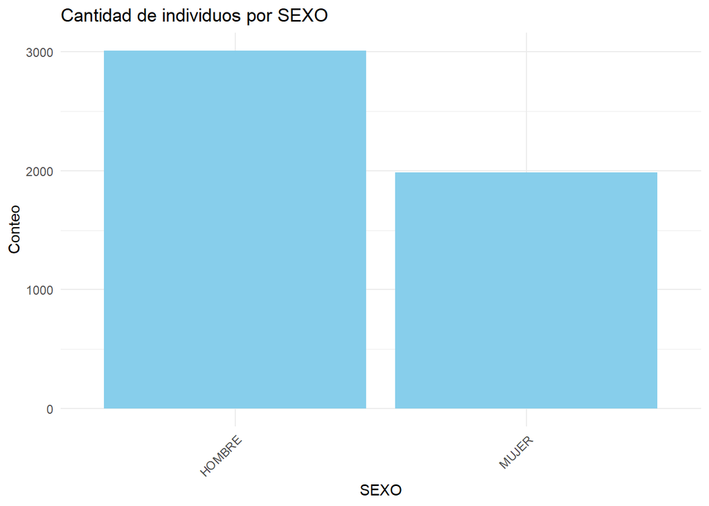

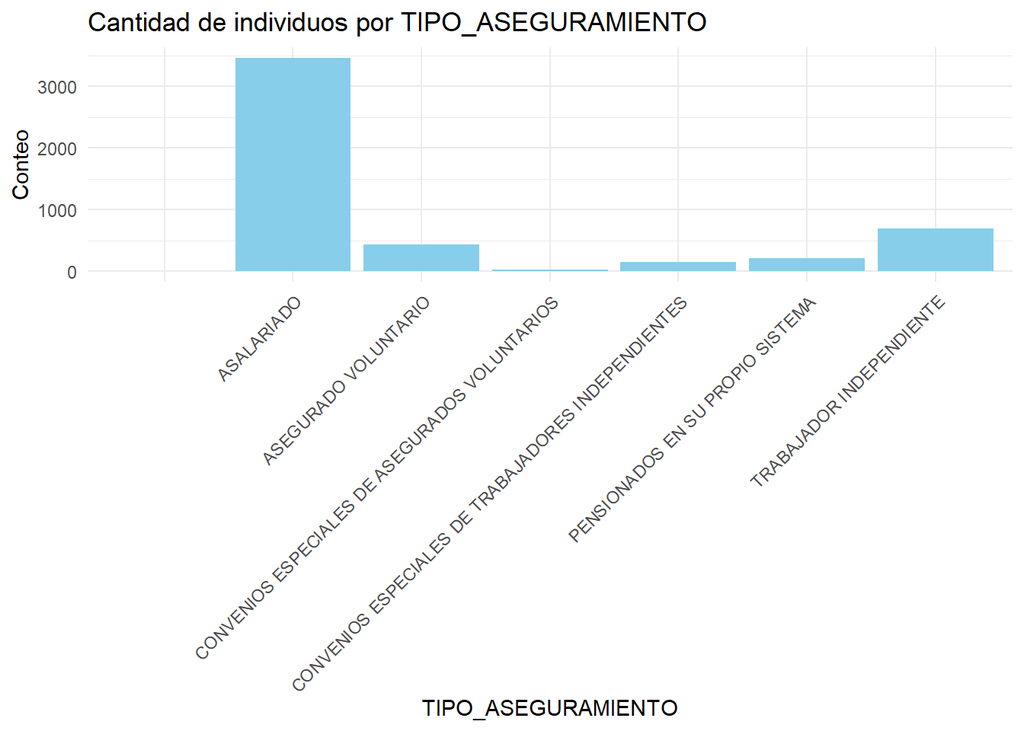

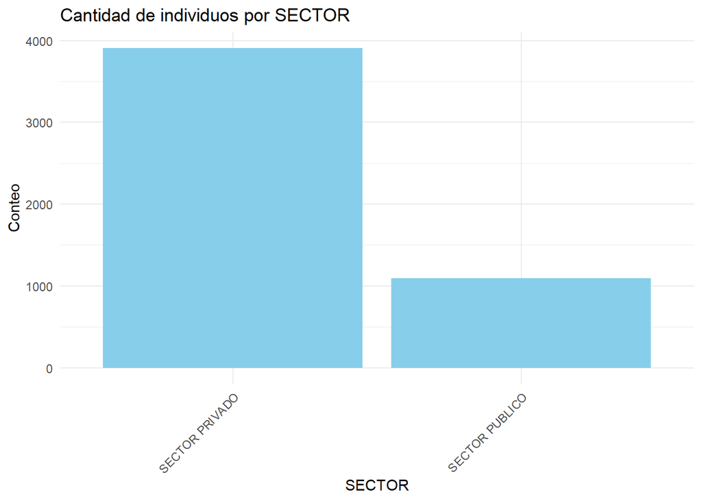

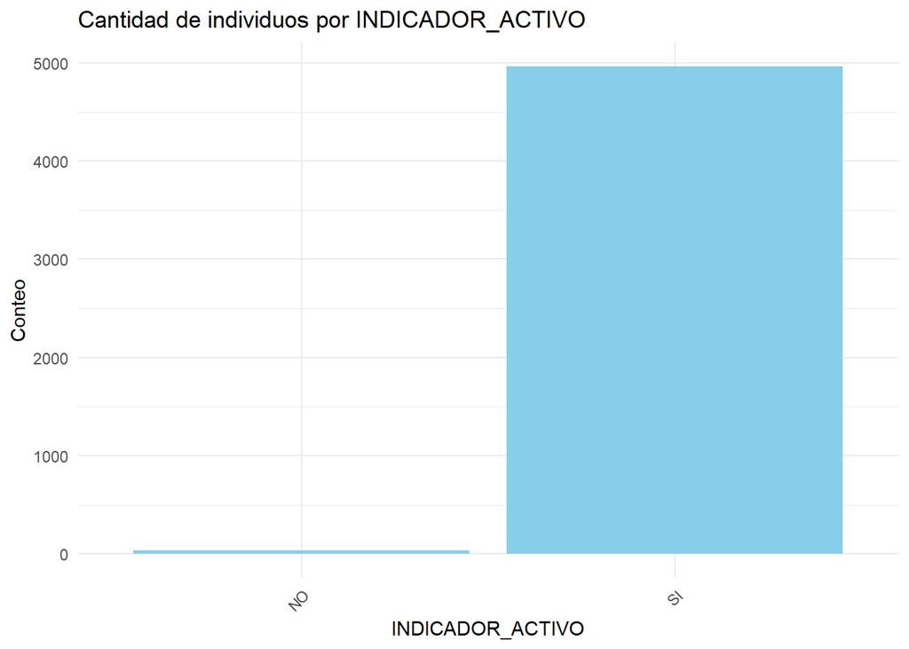

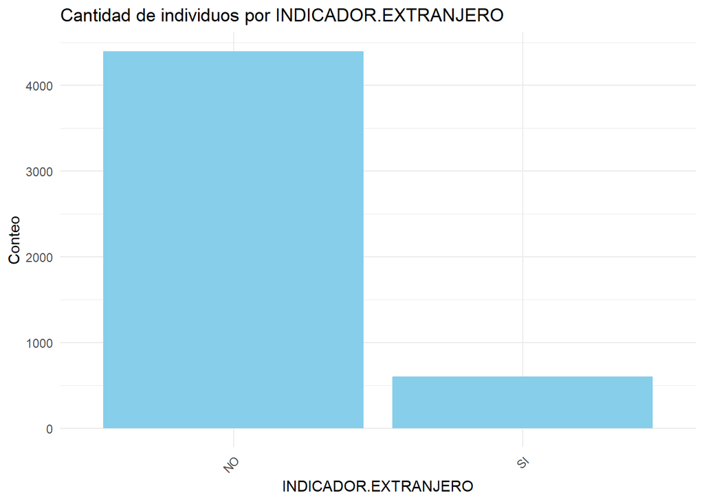

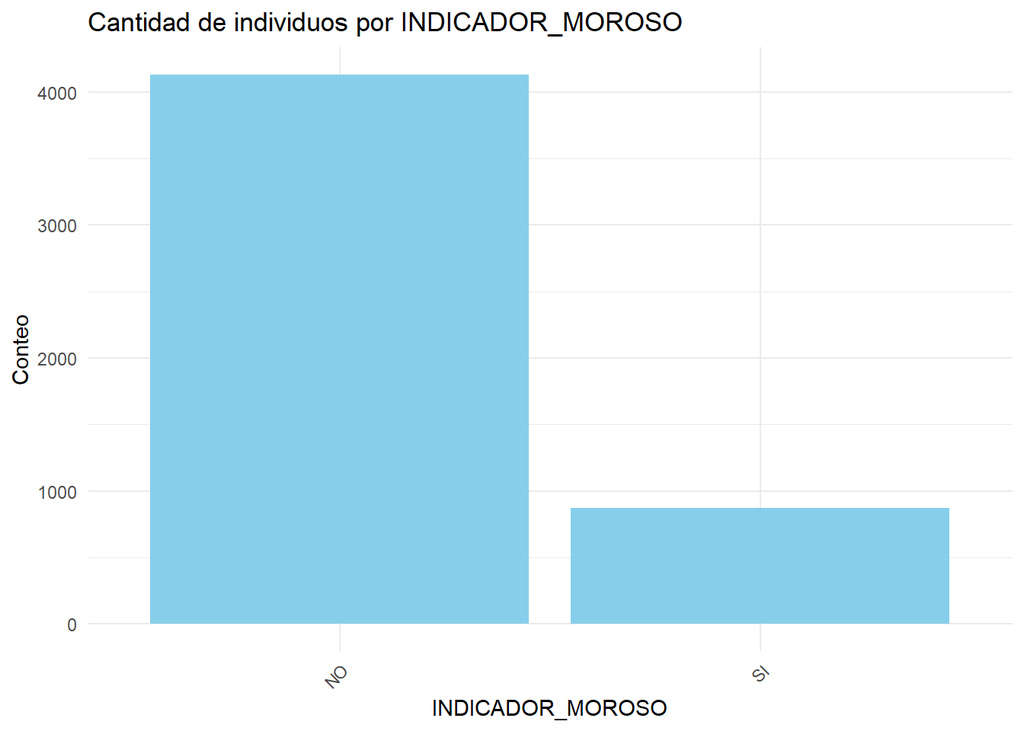

```r
variables_categoricas <- c("SEXO","TIPO_ASEGURAMIENTO",
"SECTOR","INDICADOR_ACTIVO","INDICADOR.EXTRANJERO","INDICADOR_MOROSO")

graficar_categorias <- function(df, variable) {
  ggplot(df, aes(x = .data[[variable]])) +
    geom_bar(fill = "skyblue") +
    labs(
      title = paste("Cantidad de individuos por", variable),
      x = variable,
      y = "Conteo"
    ) +
    theme_minimal() +
    theme(axis.text.x = element_text(angle = 45, hjust = 1))
}

for (j in variables_categoricas) {
  print(graficar_categorias(moras, j))
}
```

**Gráfico de SEXO:** Vemos que en la base de datos hay más hombres que mujeres  
**Gráfico de TIPO_DE_ASEGURAMIENTO:** La mayor concentración de personas está en los asalariados y la menor cantidad está dentro de los convenios especiales.  
**Gráfico por SECTOR:** Se puede notar una gran diferencia entre ambos sectores, hay mas concentracion en el sector privado que en el público  
**Gráfico de INDICADOR_ACTIVO:** La mayor parte de las personas, aún cuentan con un seguro activo.  
**Gráfico por INDICADOR.EXTRANJERO:** Se puede difrenciar la cantidad de personas nacionales y extranjeras dentro de la base de datos.  
**Gráfico por INDICADOR_MOROSO** **:** Hay más personas NO morosas que morosas,

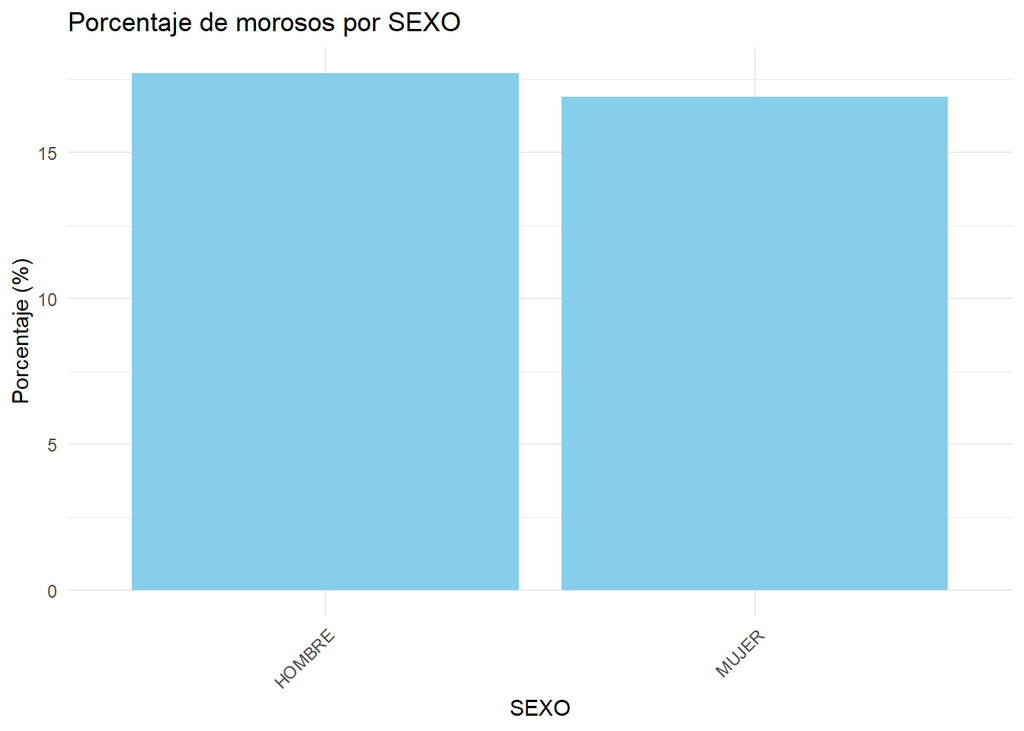

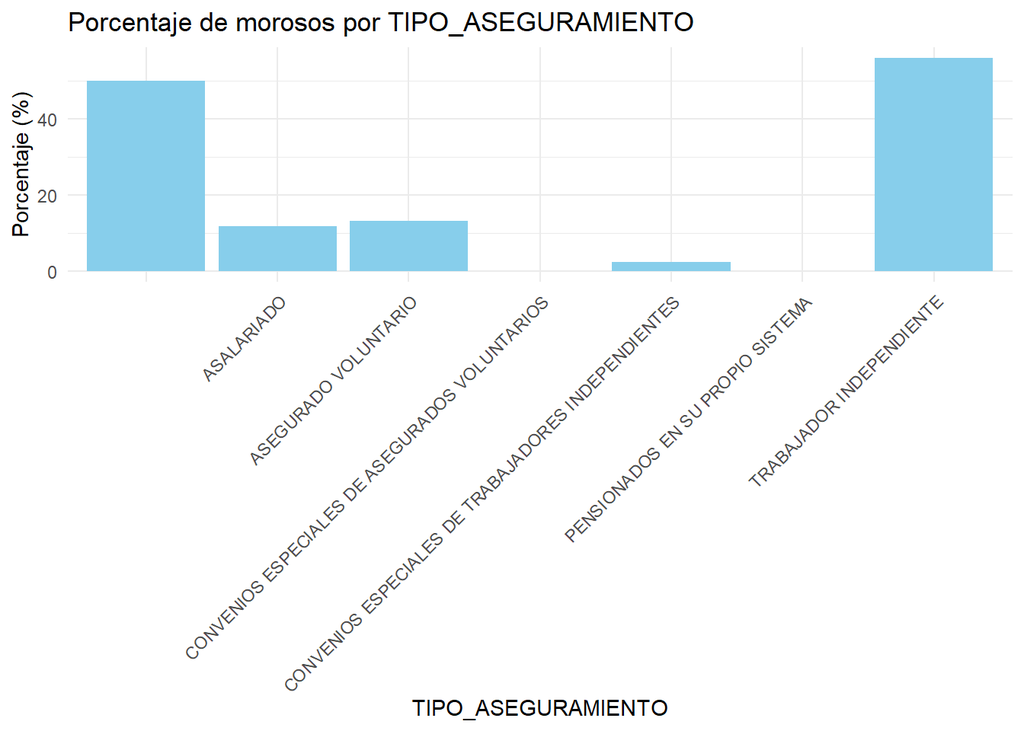

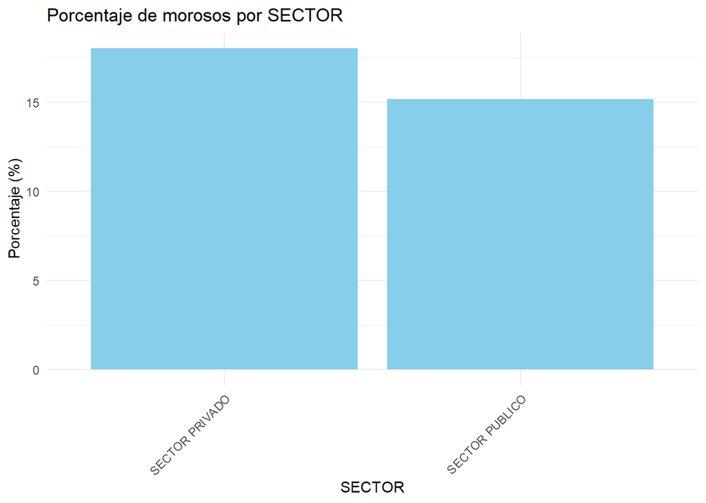

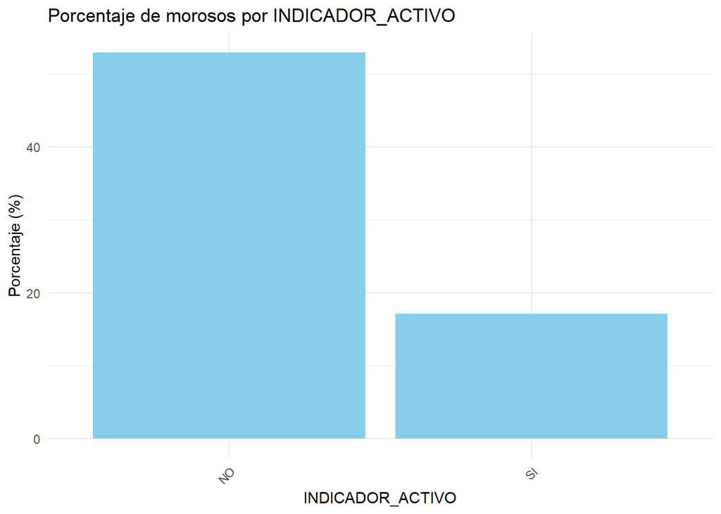

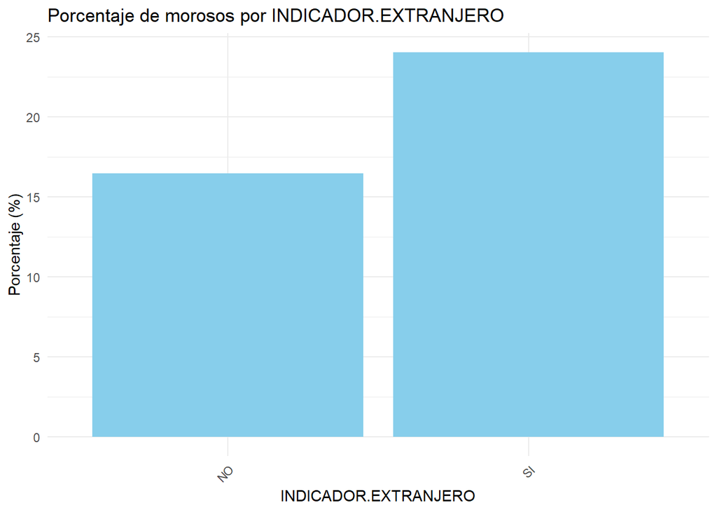

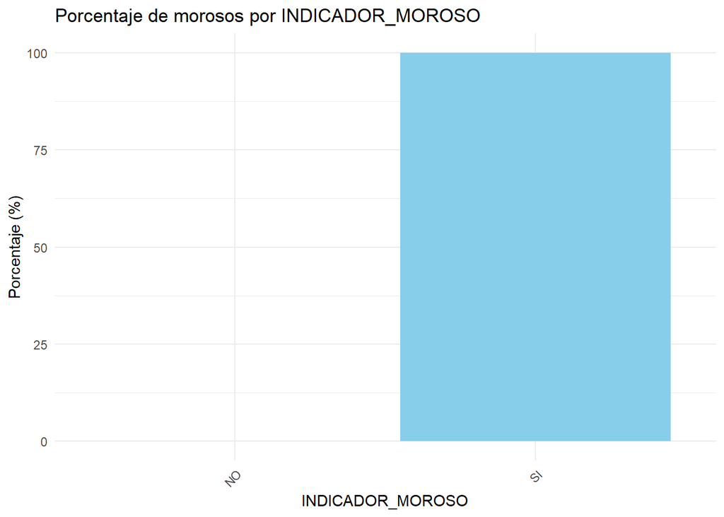

```r
graficar_morosos <- function(data, variable){

  data %>%
    group_by(.data[[variable]]) %>%
    summarise(
      total = n(),
      morosos = sum(INDICADOR_MOROSO == "SI"),
      porcentaje = morosos / total * 100
    ) %>%
    ggplot(aes(x = .data[[variable]], y = porcentaje)) +
    geom_col(fill="skyblue") +
    labs(
      title = paste("Porcentaje de morosos por", variable),
      x = variable,
      y = "Porcentaje (%)"
    ) +
    theme_minimal()+
    theme(axis.text.x = element_text(angle = 45, hjust = 1))
}

for(j in variables_categoricas){
  print(graficar_morosos(moras,j))
}
```

**Gráficos de morosos por sexo:** Dentro de la base de datos hay más hombres morosos que mujeres morosas.  
**Gráficos de morosos por tipo de aseguramiento:** El tipo de seguro donde hay mayor porcentaje de morosos, es en los de trabajores independientes, puede deberse a la estabilidad laboral de las personas que adquieren este tipo de seguro, ya que tienen en teoría tienen un trabajo propio.  
**Gráficos de morosos por sector:** Mantienen porcetajes similares, pero como la mayor cantidad está en el sector privado, quiere decir que hay mas morosos en el sector privado que en el público.  
**Gráficos de morosos por activo:** Las personas que no tienen el seguro activo, puede ser por dos cosas, porque ya no lo quieren o porque no lo pagaron, y eso se evidencia en el gráfico mostrando un alto porcentaje de morosos con el seguro no activo.  
**Gráficos de morosos por extranjeros:** Una gran parte de las personas extranjeras son morosas.